# Question

Consider the $L$-system (and turn angle) defined below:

- Start: `A`
- Rules:  
  `A > +BA-A--B--A-AB+`  
  `B > -AB+B++A++B+BA-`
- Number of recursions (number of iterations):
  - 5
- Turn angle
  - 60°

Please use [this online tool](https://artockthedino.github.io/lsys.html) to generate the pattern using turtle graphics. Choose the matching pattern. (I think the initial angle should be $270$ degrees to match exactly.)

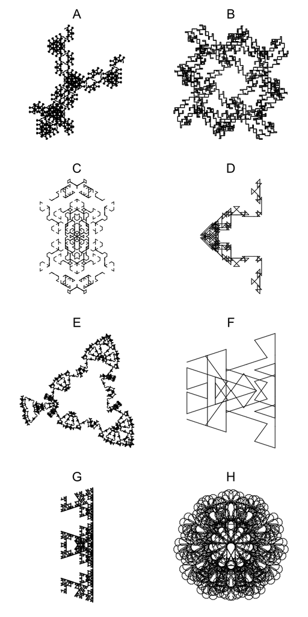

## Answerlist

- A
- B
- C
- D
- E
- F
- G
- H

# Solution

The correct pattern is pattern A.

1. Use the first link: https://artockthedino.github.io/lsys.html
2. Copy/paste the `Axiom`, `Rules`, `Iterations`, and `Turn angle`.
3. Click `Generate Pattern`
4. Back to the quiz, select the matching pattern.

In case you’re interested in the parameters of the other patterns shown:

## Pattern A

- Start: `A`
- Rules:  
  `A > +BA-A--B--A-AB+`  
  `B > -AB+B++A++B+BA-`
- Number of recursions (number of iterations):
  - 5
- Angle
  - 60

## Pattern B

- Start: `A+A+A+A`
- Rules:  
  `A > C[++CB][--CB]`  
  `B > C-BAB+C`  
  `C > CAB`
- Number of recursions (number of iterations):
  - 6
- Angle
  - 90

## Pattern C

- Start: `AA`
- Rules:  
  `A > +B-AXB---ACA---BXA-B+`  
  `B > -A++BXA+C+AXB++A-`  
  `C > C+C`  
  `X > XXX`
- Number of recursions (number of iterations):
  - 3
- Angle
  - 60

## Pattern D

- Start: `A`
- Rules:  
  `A > B-ABA-B`  
  `B > A+B+A`
- Number of recursions (number of iterations):
  - 4
- Angle
  - 135

## Pattern E

- Start: `A`
- Rules:  
  `A > +BA+A-ABA-A+AB+`  
  `B > +BBA-B--B-ABB+`
- Number of recursions (number of iterations):
  - 4
- Angle
  - 69

## Pattern F

- Start: `A`
- Rules:  
  `A > +B-AA-B+`  
  `B > -A+BB+A-`
- Number of recursions (number of iterations):
  - 3
- Angle
  - 108

## Pattern G

- Start: `AA`
- Rules:  
  `A > +B-AAA-B+`  
  `B > -A+BBB+A-`
- Number of recursions (number of iterations):
  - 5
- Angle
  - 108

## Pattern H

- Start: `A++++++.A`
- Rules:  
  `A > B+B+B+B+B+B+B`  
  `B > B[-CCA][+CCA]`  
  `C > CC`
- Number of recursions (number of iterations):
  - 5
- Angle
  - 30

# Meta-information

extype: schoice exsolution: 10000000 exname: lsys_pattern